# Using Mendeley Together With RMarkdown

Peter von Rohr

2019-01-17

## Disclaimer

This notebook shows a few experiments how to use Mendeley reference manager with Rmarkdown documents.

## Background

Mendeley can export its literature data into `bib`-files. The user can choose between the two options of

1. storing all reference in one `bib`-file or
2. creating a separate `bib`-file for each literature item.

In both cases, the generated `bib`-files are stored in a given directory. This directory must be known in order to find the `bib`-files that we are going to use to generate the references in our Rmarkdown document.

## Pre-requisites

For the sake of this demo, we are just fixing the directory where all the `bib`-files are stored in a simple variable called `s_bib_dir`.

```r
s_bib_dir <- "/Users/peter/Data/mendeley/bibtex"
```

Let us have a look at the first few entries of this directory

```r
head(list.files(path = s_bib_dir))
```

```
[1] "ABRI2018.bib"     "Aby2012.bib"      "Aby2014.bib"      "ABZ2017.bib"      "Adewuyi2005.bib"  "Agristat2018.bib"
```

## Functionality

We can distinguish between two different usage modes which are important in the design of the required functionality. The two usages modes are

1. insert a reference to a new bibliography record
2. insert a reference to a bibliography record that has already been reference in the current document.

### Reference To A New Bibliography Record

The most important functionality for the tools to be developed is the possibility to enter a given new `citation-key` and from that key, all entries in the directory `s_bib_dir` are searched and the reference to the desired bibliography record is created in the document and the information of the `bib`-file is copied into a single local `bib`-file that is specific for the current document.

[figure not shown]

The creation of a local copy of the information of the `bib`-file is required to be able to allow that other authors can also build the document from the Rmarkdown sources, even when they do not have access to an own mendeley `bib`-directory.

### Reference To An Already Existing Bibliography Record

As soon as a bibliography record has already been cited in the current document, its `bib`-entry has already been copied to the local `bib`-file and with that the RStudio-Addin `citr` can be used to insert the reference.

## Mendeley Data Export

The reference manager `Mendeley` can export its records in bib-format into either

- one single `bib`-file or
- into many `bib`-files, one record per exported file.

In which way `Mendeley` exports its records can be set as an option under `Preferences` > `BibTex` as shown in the figure below.

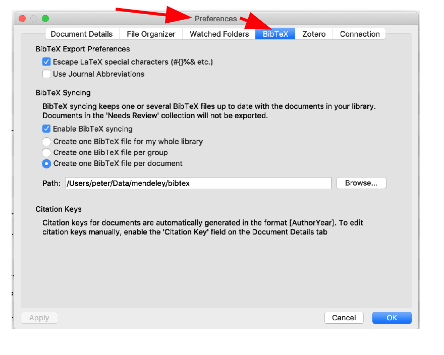

In the BibTeX-Preference Menu the path to the directory where the exported file(s) are saved is also specified. This bath is what we saved under the variable `s_bib_dir`. From the result of the BibTeX-export, we can detect which of the options was set in `Mendeley`. If the directory `s_bib_dir` contains just one file, then the first option of creating just one BibTeX file for the whole library is specified, otherwise either option two or three were chosen.

In our case the number of files in `s_bib_dir` can be determined by

```r
(n_nr_bib_files <- length(list.files(path = s_bib_dir)))
```

```
[1] 247
```

Because this number is greater than one, our way of determining the export option is consistent with the option shown in the screenshot.

## Create Local BibTeX File

To create the local BibTeX file the following information is required

- path to the mendeley export directory. In this document here this is set to the variable `s_bib_dir`. But at a later stage, we have to move this into the `options()` list or, we can set it explicitly by the initialisation of the described tool
- the nae of the local BibTeX file. This can be chosen to be the same as the Rmd source file with extension .bib instead of .Rmd.
- the citation key of the literature reference that is to be included at any given position of the Rmd source document.

## Information Storage

The above listed information is best manage using a R6-object. The path to the mendeley export directory and the name of the local BibTeX file is stored as ordinary text fields.

```r
MendeleyExporter <- R6::R6Class(classname = "MendeleyExporter",
                                public = list(
                                  initialize = function(){
                                    private$s_men_export_dir <- getOption("rmddh.mendeley.export.dir")
                                    private$s_local_bib_file <- "bibliography.bib"
                                  },
                                  ### # setter and getter for s_men_export_dir
                                  set_mendeley_export_dir = function(ps_men_export_dir){private$s_men_export_dir <- ps_men_export_dir},
                                  get_mendeley_export_dir = function(){return(private$s_men_export_dir)},
                                  ### # setter and getter for s_local_bib_file
                                  set_local_bib_file = function(ps_local_bib_file){private$s_local_bib_file <- ps_local_bib_file},
                                  get_local_bib_file = function(){return(private$s_local_bib_file)},
                                  ### # add a BibTeX-record to the local bib file
                                  add = function(ps_new_ref){
                                    ### # obtain ps_ref from mendeley export dir
                                    vec_bib_new_ref <- private$get_bib_from_mendeley_export(ps_new_ref)
                                    ### # write the new version of the local bib file
                                    private$write_local_bib(pvec_bib_new_ref = vec_bib_new_ref)
                                  }
                                ),
                                private = list(
                                  s_men_export_dir = NA,
                                  s_local_bib_file = NA,
                                  ### # private functions
                                  ### # get the bib-record for ps_new_ref from mendeley export
                                  get_bib_from_mendeley_export = function(ps_new_ref){
                                    ### # check that we know were mendeley export dir is and that it exists
                                    if (!dir.exists(private$s_men_export_dir))
                                      stop("[ERROR -- get_bib_from_mendeley_export] Cannot find mendeley export directory: ", private$s_men_export_dir)
                                    ### # distinguish between all mendeley exports in one file or in separate files
                                    vec_mendeley_export_bib <- list.files(path = private$s_men_export_dir, pattern = "bib$")
                                    if ( length(vec_mendeley_export_bib) == 1 ){
                                      ### # all references are in one file
                                      s_all_ref <- RefManageR::ReadBib(file = file.path(private$s_men_export_dir,vec_mendeley_export_bib))
                                      s_new_ref <- s_all_ref[ps_new_ref]
                                    } else {
                                      ### # each reference has a separate file
                                      s_new_bib_file <- file.path(private$s_men_export_dir, paste0(ps_new_ref, ".bib"))
                                      if (!file.exists(s_new_bib_file))
                                        stop("[ERROR -- get_bib_from_mendeley_export] Cannot find bib file for reference: ", ps_new_ref)
                                      s_new_ref <- RefManageR::ReadBib(file = s_new_bib_file)
                                    }
                                    ### # check whether, we found a bib entry for ps_new_ref
                                    if (length(s_new_ref) == 0)
                                      stop("[ERROR -- get_bib_from_mendeley_export] Cannot find bib entry for reference: ", ps_new_ref)
                                    return(s_new_ref)
                                  },
                                  ### # write new version of local bib-file with pvec_bib_new_ref in it, if it is not already included
                                  write_local_bib = function(pvec_bib_new_ref){
                                    ### # read existing local references from s_local_bib_file, if it exists already
                                    if (file.exists(private$s_local_bib_file)){
                                      vec_local_bib <- RefManageR::ReadBib(file = private$s_local_bib_file)
                                      ### # add pvec_bib_new_ref, if it is not yet included
                                      if ( length(vec_local_bib[names(pvec_bib_new_ref)]) == 0 )
                                        vec_local_bib <- c(vec_local_bib, pvec_bib_new_ref)
                                    } else {
                                      vec_local_bib <- pvec_bib_new_ref
                                    }
                                    ### # add new ref to local bib file
                                    RefManageR::WriteBib(vec_local_bib, file = private$s_local_bib_file)
                                    return(invisible(TRUE))
                                  }
                                ))
```

## Calling the Main Functionality

As the first step the above defined `R6` class must be instantiated into an object.

```r
ref <- MendeleyExporter$new()
ref$add("Meuwissen2001")
```

```
Writing 1 Bibtex entries ... OK
Results written to file ‘bibliography.bib’
```

In a second step the inline call to add the reference should be replaced by the string that includes the reference. To do this we need to know the path to the current Rmd file. One way of doing this is to use the `rstudioapi` package as shown below.

```r
if (rstudioapi::isAvailable()){
  s_cur_path <- rstudioapi::getSourceEditorContext()$path
} else {
  s_cur_path <- here::here()
}
cat("Path to current file: ", s_cur_path)
```

```
Path to current file:  ~/Data/Projects/GitHub/pvrqualitasag/use-mendeley/20190117_use_mendeley_with_rmd/20190117_use_mendeley_with_rmd.Rmd
```